# Homework 4

Mari Sanders

2024-11-15

# Problem 1

$H_0:$ The median blood sugar reading is 120

$H_1:$ The median blood sugar reading is less than 120.

```r
blood_sugar <- c(125,123,117, 123, 115, 112, 128, 118, 124, 111, 116,
                       109, 125, 120, 113, 123, 112, 118, 121, 118, 122, 115,105,
                       118, 131)

SIGN.test(blood_sugar, md = 120, alternative = "less")
```

```
##
##  One-sample Sign-Test
##
## data:  blood_sugar
## s = 10, p-value = 0.2706
## alternative hypothesis: true median is less than 120
## 95 percent confidence interval:
##      -Inf 122.1203
## sample estimates:
## median of x
##         118
##
## Achieved and Interpolated Confidence Intervals:
##
##                   Conf.Level L.E.pt   U.E.pt
## Lower Achieved CI     0.9461   -Inf 122.0000
## Interpolated CI       0.9500   -Inf 122.1203
## Upper Achieved CI     0.9784   -Inf 123.0000
```

The `p-value` is 0.2706, which means we would fail to reject the null hypothesis that the median blood sugar reading is 120. The `test_statistic` is 10.

$H_0:$ The median blood sugar readings is 120.

$H_1:$ The median blood sugar readings is less than 120.

```r
wilcox.test(blood_sugar, mu = 120, alternative = "less")
```

```
##
##  Wilcoxon signed rank test with continuity correction
##
## data:  blood_sugar
## V = 112.5, p-value = 0.1447
## alternative hypothesis: true location is less than 120
```

The `p_value` is 0.1447, which means we would fail to reject the null hypothesis that the median blood sugar readings is equal to 120. The `test_statistic` is 112.5.

# Problem 2

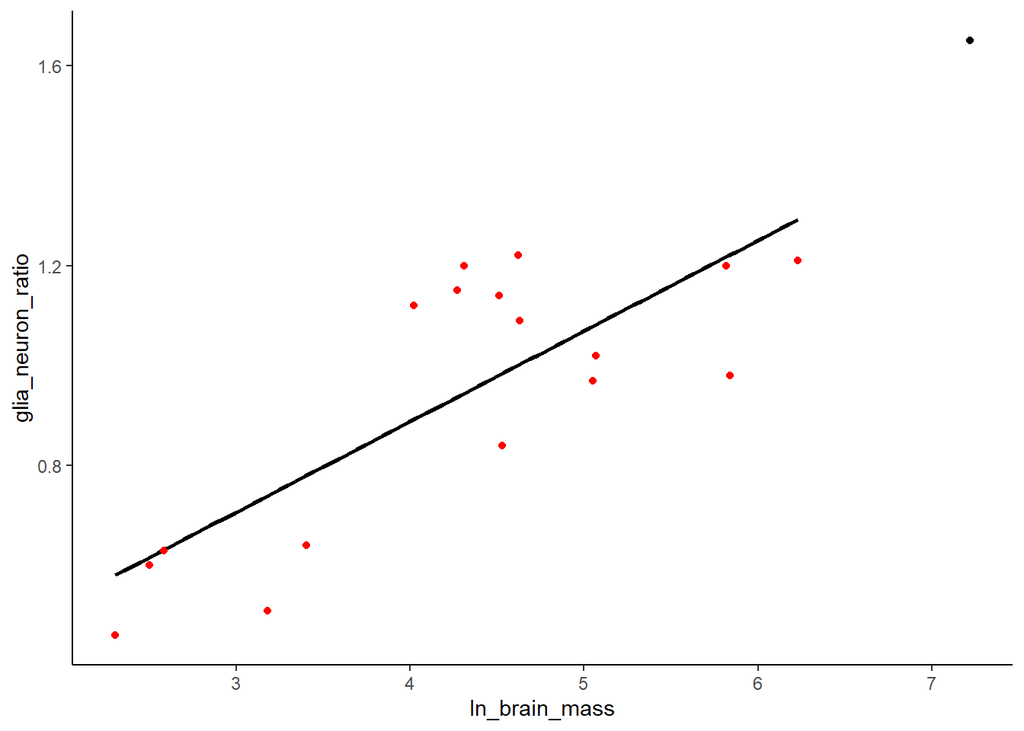

```r
brain <- read_xlsx("data/Brain.xlsx") %>% janitor::clean_names()
brain %>%
  slice(-1) %>%
  ggplot(aes(x = ln_brain_mass, y = glia_neuron_ratio)) +
  geom_smooth(method = "lm", se = FALSE, color = "black") +
  geom_point(color = "red") +
  geom_point(aes(x = brain$ln_brain_mass[1],
                 y = brain$glia_neuron_ratio[1])) +
  guides(color = "none") +
  theme_classic()
```

```r
human_ln_brain_mass <- brain$ln_brain_mass[1]

non_human_model <- lm(glia_neuron_ratio ~ ln_brain_mass, data = brain %>% slice(-1))

broom::tidy(non_human_model)
```

```
## # A tibble: 2 × 5
##   term          estimate std.error statistic  p.value
##   <chr>            <dbl>     <dbl>     <dbl>    <dbl>
## 1 (Intercept)      0.164    0.160       1.02 0.322
## 2 ln_brain_mass    0.181    0.0360      5.03 0.000151
```

`glia_neuron_ratio` = 0.164 + 0.181*`ln_brain_mass`

```r
predict(non_human_model, newdata = data.frame(ln_brain_mass = human_ln_brain_mass))
```

```
##        1
## 1.471458
```

This means that human `glia_neuron_ratio` is 1.471458.

Since we want to look at humans compared to nonhuman primates, the interval for a prediction of a single new observation. This is because our dataset does not have the human brain mass data and we want to see if it can predict the value.

```r
predict(non_human_model, newdata = data.frame(ln_brain_mass = human_ln_brain_mass), interval = "prediction", level = 0.95)
```

```
##        fit      lwr      upr
## 1 1.471458 1.036047 1.906869
```

```r
mean(brain$glia_neuron_ratio)
```

```
## [1] 0.9794444
```

```r
mean(brain$ln_brain_mass)
```

```
## [1] 4.448889
```

We are 95% confident that the predicted glia-neuron ratio for humans is between 1.036047 and 1.906869.

The position of the human data point might pull the regression line to it and might not accurately predict the rest of the data points. This would be extrapolation.

# Problem 3

```r
heart_disease <- read_csv("data/HeartDisease.csv")
```

```r
heart_disease %>%
  summarize(
    mean_totalcost = mean(totalcost, na.rm = TRUE),
    median_totalcost = median(totalcost, na.rm = TRUE),
    sd_totalcost = sd(totalcost, na.rm = TRUE),
    mean_ervisits = mean(ERvisits, na.rm = TRUE),
    sd_ervisits = sd(ERvisits, na.rm = TRUE),
    mean_age = mean(age, na.rm = TRUE),
    sd_age = sd(age, na.rm = TRUE),
    mean_complications = mean(complications, na.rm = TRUE),
    sd_complications = sd(complications, na.rm = TRUE),
    mean_duration = mean(duration, na.rm = TRUE),
    sd_duration = sd(duration, na.rm = TRUE)
  ) %>% knitr::kable()
```

| mean_totalcost | median_totalcost | sd_totalcost | mean_ervisits | sd_ervisits | mean_age | sd_age | mean_complications | sd_complications | mean_duration | sd_duration |
| --- | --- | --- | --- | --- | --- | --- | --- | --- | --- | --- |
| 2799.956 | 507.2 | 6690.26 | 3.425127 | 2.637474 | 58.71827 | 6.754118 | 0.0571066 | 0.248068 | 164.0305 | 120.9159 |

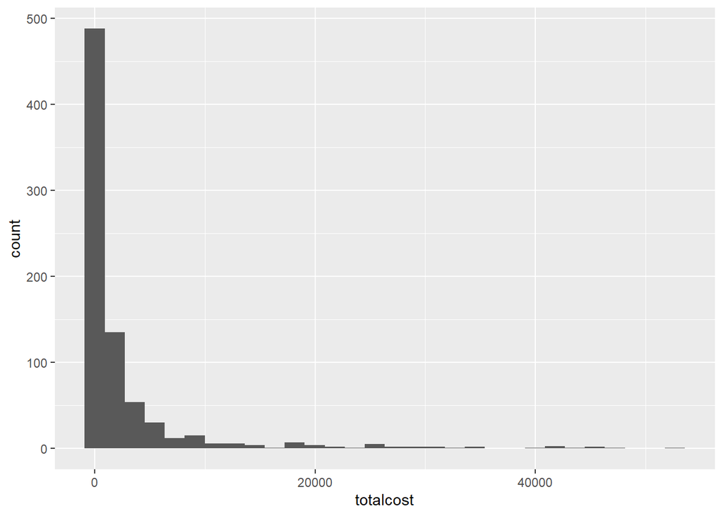

```r
heart_disease %>%
  ggplot(aes(x = totalcost)) + geom_histogram()
```

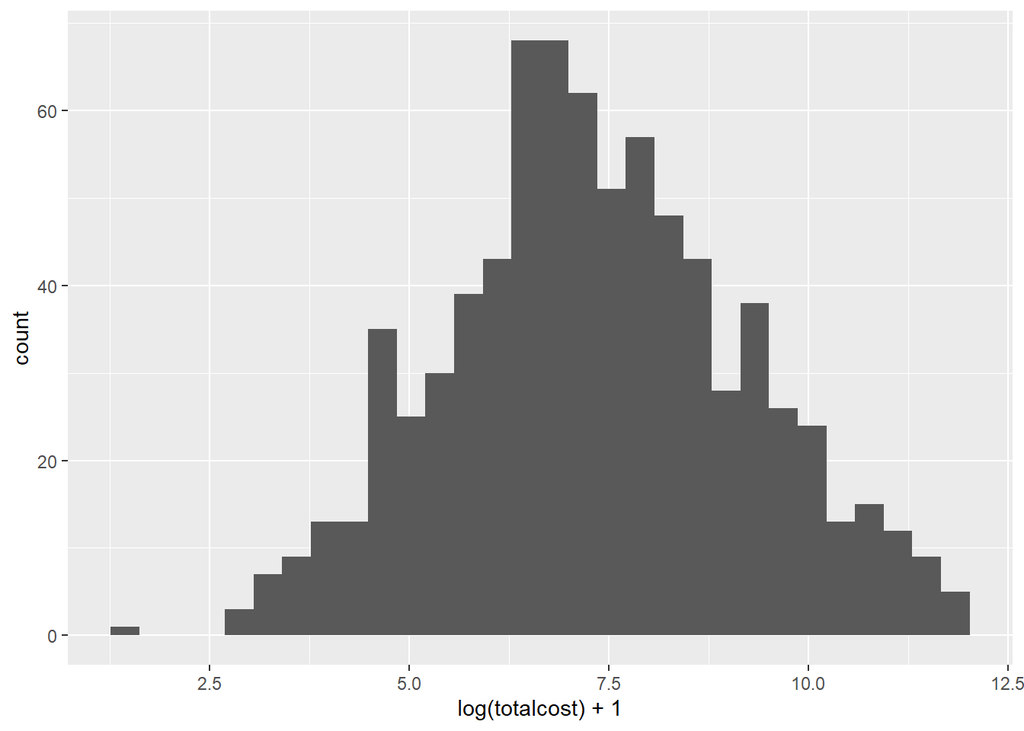

```r
heart_disease %>%
  ggplot(aes(x = log(totalcost) + 1)) + geom_histogram()
```

Doing a log transformation seems to make the data look more normal. It originally looked exponential.

```r
heart_data <-
  heart_disease %>%
  drop_na() %>%
  mutate(comp_bin = ifelse(complications > 0, 1, 0),
         log_totalcost = log(totalcost + 1))
```

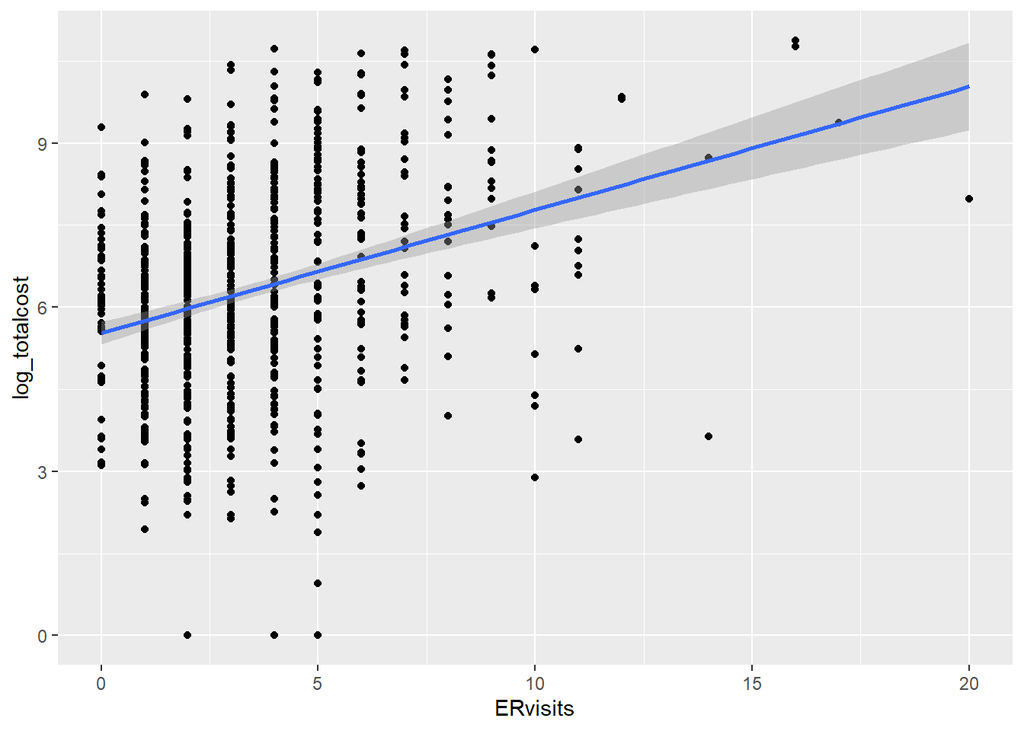

```r
heart_data %>%
  ggplot(aes(x = ERvisits, y = log_totalcost)) + geom_point() + geom_smooth(method = lm)
```

```r
model <- lm(log_totalcost~ERvisits, data = heart_data)
broom::tidy(model)
```

```
## # A tibble: 2 × 5
##   term        estimate std.error statistic   p.value
##   <chr>          <dbl>     <dbl>     <dbl>     <dbl>
## 1 (Intercept)    5.53     0.105      52.6  1.32e-259
## 2 ERvisits       0.225    0.0243      9.26 1.84e- 19
```

Testing for Effect Modifications

```r
mlr <- lm(log_totalcost ~ ERvisits*comp_bin , data = heart_data)

broom::tidy(mlr)
```

```
## # A tibble: 4 × 5
##   term              estimate std.error statistic   p.value
##   <chr>                <dbl>     <dbl>     <dbl>     <dbl>
## 1 (Intercept)         5.49      0.105      52.3  1.04e-257
## 2 ERvisits            0.209     0.0249      8.41 1.90e- 16
## 3 comp_bin            2.19      0.554       3.95 8.47e-  5
## 4 ERvisits:comp_bin  -0.0975    0.0963     -1.01 3.11e-  1
```

`comp_bin` is significant, but the interaction between `ERvisits` and `comp_bin` is not significant. This means that since `comp_bin` is not an effect modifier in the relationship between `totalcost` and `ERvisits`.

Testing for Confounding

```r
heart_data %>%
  filter(comp_bin == 1) %>%
  lm(log_totalcost ~ERvisits, data = .) %>%
  broom::tidy()
```

```
## # A tibble: 2 × 5
##   term        estimate std.error statistic  p.value
##   <chr>          <dbl>     <dbl>     <dbl>    <dbl>
## 1 (Intercept)    7.68     0.389      19.8  1.44e-22
## 2 ERvisits       0.112    0.0664      1.69 9.94e- 2
```

```r
heart_data %>%
  filter(comp_bin == 0) %>%
  lm(log_totalcost ~ERvisits, data = .) %>%
  broom::tidy()
```

```
## # A tibble: 2 × 5
##   term        estimate std.error statistic   p.value
##   <chr>          <dbl>     <dbl>     <dbl>     <dbl>
## 1 (Intercept)    5.49     0.106      51.6  9.84e-248
## 2 ERvisits       0.209    0.0252      8.30 4.89e- 16
```

Since `comp_bin` does not change the slope significantly, does not change the directionality, and since the interaction is not significant, it is not a confounder.

I think that `comp_bin` should be included in the model because it is significant in the model, even though it is not a confounder and it is not an effect modifier. It is independently associated with `log_totalcost` based on it being signficiant, so it should be included.

```r
extended_model <- lm(log_totalcost ~ ERvisits + I(comp_bin) + age + I(gender) + duration, data = heart_data)
summary(extended_model)
```

```
##
## Call:
## lm(formula = log_totalcost ~ ERvisits + I(comp_bin) + age + I(gender) +
##     duration, data = heart_data)
##
## Residuals:
##     Min      1Q  Median      3Q     Max
## -5.4711 -1.0340 -0.1158  0.9493  4.3372
##
## Coefficients:
##               Estimate Std. Error t value Pr(>|t|)
## (Intercept)  5.9404610  0.5104064  11.639  < 2e-16 ***
## ERvisits     0.1745975  0.0225736   7.735 3.20e-14 ***
## I(comp_bin)  1.5044946  0.2584882   5.820 8.57e-09 ***
## age         -0.0206475  0.0086746  -2.380   0.0175 *
## I(gender)   -0.2067662  0.1387002  -1.491   0.1364
## duration     0.0057150  0.0004888  11.691  < 2e-16 ***
## ---
## Signif. codes:  0 '***' 0.001 '**' 0.01 '*' 0.05 '.' 0.1 ' ' 1
##
## Residual standard error: 1.624 on 782 degrees of freedom
## Multiple R-squared:  0.2694, Adjusted R-squared:  0.2647
## F-statistic: 57.68 on 5 and 782 DF,  p-value: < 2.2e-16
```

```r
broom::tidy(extended_model)
```

```
## # A tibble: 6 × 5
##   term        estimate std.error statistic  p.value
##   <chr>          <dbl>     <dbl>     <dbl>    <dbl>
## 1 (Intercept)  5.94     0.510        11.6  5.49e-29
## 2 ERvisits     0.175    0.0226        7.73 3.20e-14
## 3 I(comp_bin)  1.50     0.258         5.82 8.57e- 9
## 4 age         -0.0206   0.00867      -2.38 1.75e- 2
## 5 I(gender)   -0.207    0.139        -1.49 1.36e- 1
## 6 duration     0.00572  0.000489     11.7  3.26e-29
```

```r
final_model <- lm(log_totalcost ~ ERvisits + comp_bin + age + gender + duration, data = heart_data)
summary(final_model)
```

```
##
## Call:
## lm(formula = log_totalcost ~ ERvisits + comp_bin + age + gender +
##     duration, data = heart_data)
##
## Residuals:
##     Min      1Q  Median      3Q     Max
## -5.4711 -1.0340 -0.1158  0.9493  4.3372
##
## Coefficients:
##               Estimate Std. Error t value Pr(>|t|)
## (Intercept)  5.9404610  0.5104064  11.639  < 2e-16 ***
## ERvisits     0.1745975  0.0225736   7.735 3.20e-14 ***
## comp_bin     1.5044946  0.2584882   5.820 8.57e-09 ***
## age         -0.0206475  0.0086746  -2.380   0.0175 *
## gender      -0.2067662  0.1387002  -1.491   0.1364
## duration     0.0057150  0.0004888  11.691  < 2e-16 ***
## ---
## Signif. codes:  0 '***' 0.001 '**' 0.01 '*' 0.05 '.' 0.1 ' ' 1
##
## Residual standard error: 1.624 on 782 degrees of freedom
## Multiple R-squared:  0.2694, Adjusted R-squared:  0.2647
## F-statistic: 57.68 on 5 and 782 DF,  p-value: < 2.2e-16
```

```r
broom::tidy(final_model)
```

```
## # A tibble: 6 × 5
##   term        estimate std.error statistic  p.value
##   <chr>          <dbl>     <dbl>     <dbl>    <dbl>
## 1 (Intercept)  5.94     0.510        11.6  5.49e-29
## 2 ERvisits     0.175    0.0226        7.73 3.20e-14
## 3 comp_bin     1.50     0.258         5.82 8.57e- 9
## 4 age         -0.0206   0.00867      -2.38 1.75e- 2
## 5 gender      -0.207    0.139        -1.49 1.36e- 1
## 6 duration     0.00572  0.000489     11.7  3.26e-29
```

```r
base_model <- lm(log_totalcost ~ ERvisits, data = heart_data)
summary(base_model)
```

```
##
## Call:
## lm(formula = log_totalcost ~ ERvisits, data = heart_data)
##
## Residuals:
##     Min      1Q  Median      3Q     Max
## -6.6532 -1.1230  0.0309  1.2797  4.2964
##
## Coefficients:
##             Estimate Std. Error t value Pr(>|t|)
## (Intercept)  5.52674    0.10510  52.584   <2e-16 ***
## ERvisits     0.22529    0.02432   9.264   <2e-16 ***
## ---
## Signif. codes:  0 '***' 0.001 '**' 0.01 '*' 0.05 '.' 0.1 ' ' 1
##
## Residual standard error: 1.799 on 786 degrees of freedom
## Multiple R-squared:  0.09844,    Adjusted R-squared:  0.09729
## F-statistic: 85.82 on 1 and 786 DF,  p-value: < 2.2e-16
```

```r
broom::tidy(base_model)
```

```
## # A tibble: 2 × 5
##   term        estimate std.error statistic   p.value
##   <chr>          <dbl>     <dbl>     <dbl>     <dbl>
## 1 (Intercept)    5.53     0.105      52.6  1.32e-259
## 2 ERvisits       0.225    0.0243      9.26 1.84e- 19
```

Compared to the base_model, the $r^2$ value is higher for the `final_model` that includes multiple parameters, so we should choose the `final_model` to predict `log_totalcost` from `ERvisits`